# White wine quality

sulphates are added to produce sulfur dioxide in wine so that it can prevent it from oxidation and spoilage.sulfur dioxide is present in wine as free SO2 and also bound to acetaldehyde.The sum gives the total sulfur dioxide in wine. Legal limit of SO2 is 350mg/L and the sweet wine is 400mg/L.

```
## summary of free sulfur dioxide
```

```
##    Min. 1st Qu.  Median    Mean 3rd Qu.    Max.
##    2.00   23.00   34.00   35.31   46.00  289.00
```

```
## summary of bound sulfur dioxide
```

```
##    Min. 1st Qu.  Median    Mean 3rd Qu.    Max.
##     4.0    78.0   100.0   103.1   125.0   331.0
```

```
## summary of total sulfur dioxide
```

```
##    Min. 1st Qu.  Median    Mean 3rd Qu.    Max.
##     9.0   108.0   134.0   138.4   167.0   440.0
```

```
## summary of sulphates
```

```
##    Min. 1st Qu.  Median    Mean 3rd Qu.    Max.
##  0.2200  0.4100  0.4700  0.4898  0.5500  1.0800
```

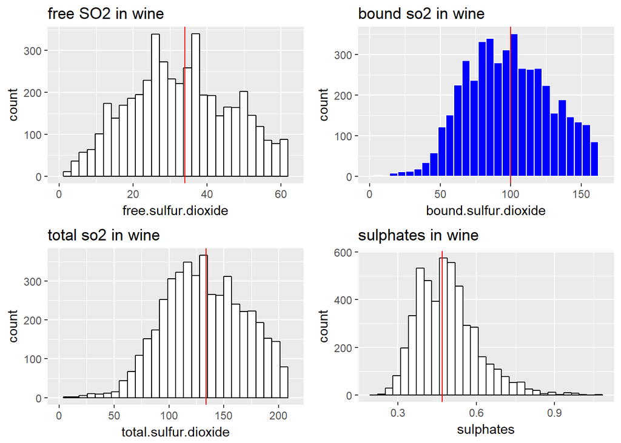

About 95% of the wine has the total sulfur dioxide that is well below the legal limit. Bound sulfur dioxide is high in number comparing to the free sulfur dioxide in wine. In other words the total sulfur dioxide contains more bound SO2 than free SO2.

**density**

Density of the wine is closer to the density of water.According to winemakers sweet wine has more density than dry wine.

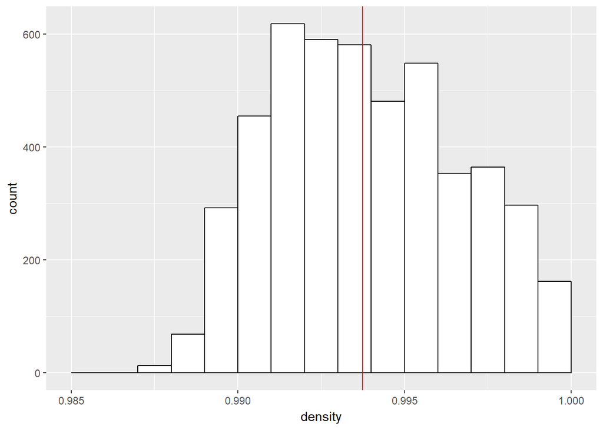

```
##    Min. 1st Qu.  Median    Mean 3rd Qu.    Max.
##  0.9871  0.9917  0.9937  0.9940  0.9961  1.0390
```

Most of the wine has density between 0.985 to 1.000. In that about 50% data falls in the range of 0.9917 to 0.9961

**quality**

Quality is the score between 0 and 10.

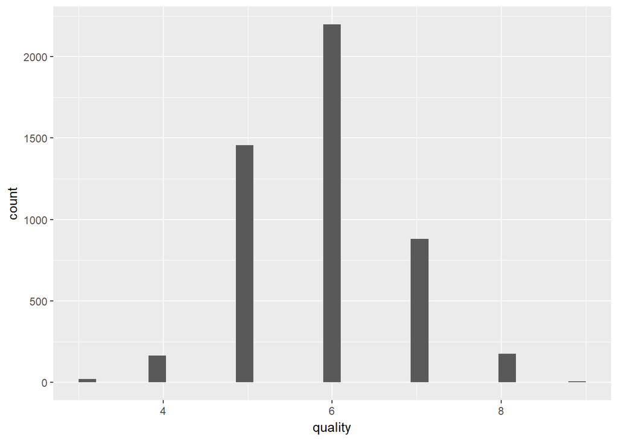

```
##    Min. 1st Qu.  Median    Mean 3rd Qu.    Max.
##   3.000   5.000   6.000   5.878   6.000   9.000
```

There is a peak at wine. It means more number of the wine has the quality as 6. Count is dropping after the quality 6. There is only 25% of the wine has more than 6 as a quality.

# univariate analysis

**What is the structure of your dataset?**

It has 4898 observations with 12 variables. In that 11 variables are of numeric datatype and one is an interger.

**What are the main features of your dataset?**

Main feature of the dataset is quality. All the other variables in the dataset contributes to the quality oneway or another. Change in the one or more variable may change the quality of the wine. So it is the main feature of the dataset.

**What other features in the dataset do you think will help your support your investigation into your feature of your dataset?**

residual sugar,alcohol,fixed acidity,volatile acidity and citric acid contribute aroma,taste and acidity to the wine so this will be important features to influence the quality of the white wine.

**Did you create any new variables in the dataset?**

Yes,I created two variables in the dataset. One is the taste_type. White wine bottles have labels to denote the sweetness.They are labeled based on the residual sugar content in the wine. So based on this i created a factor variable to denote the sweet type.

Another varaibel is bound.sulfur.dioxide. When sulphates are added it provide sulfur dioxide to the wine which inturn helps to fight againts the microbial spoilage.

**of the features you investigated, were there any unusual distributions? Did you perform any operations on the data to tidy, adjust or change the form of the data? If so,why did you do this?**

yes, density has the most unsual distribution.In density most of the wines fall in the short range that leads to more wines fall in the same bin. So i have to set the binwidth, limits and the breaks on the x axis to see how it is distributed.

# Bivariate plot section.

**fixed.acidity by pH**

pH is the measure of the acidity of the solution. Higher the pH it contains less acid and vice versa.

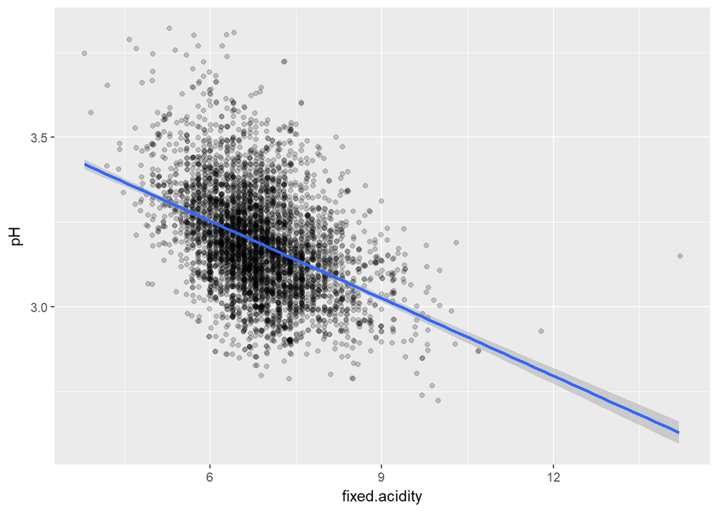

```
## [1] -0.4258583
```

This show that pH and fixed acidity are negatively correlated.This prove the concept of measuring pH.They are correlated by -0.426.

**chlorides vs quality**

Reason i choose to explore quality vs chloride is When the chloride content becomes higher in the wine, it can affects the aroma of wine which in turn may affects the quality.

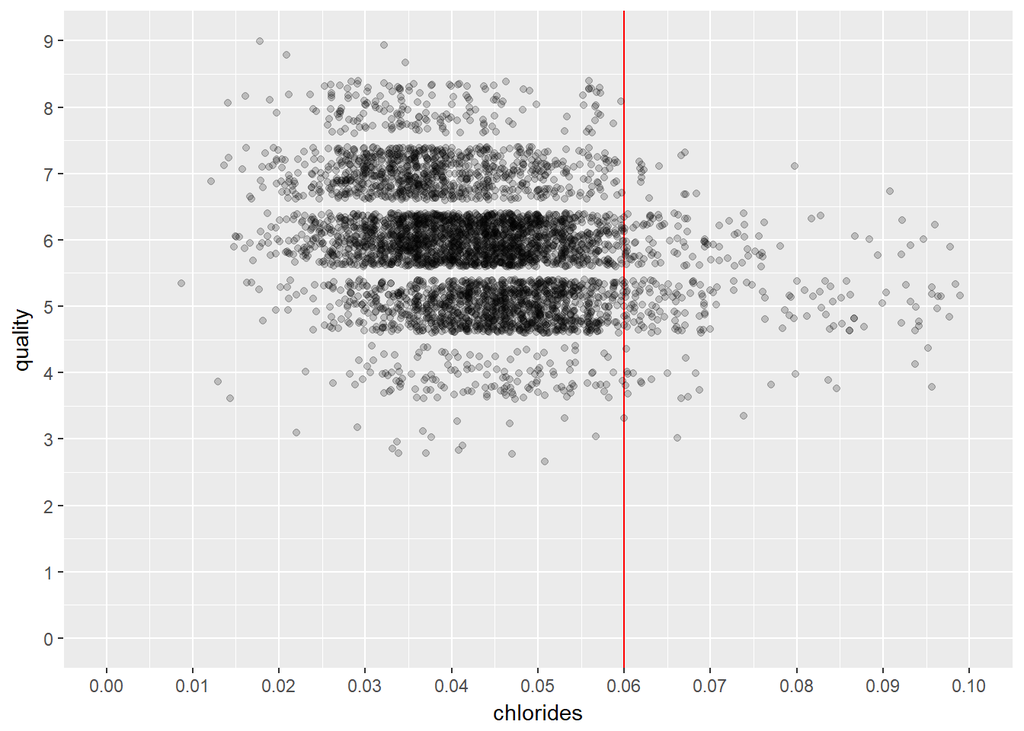

```
## [1] -0.2099344
```

**alcohol vs residual.sugar**

During fermentation, sugars present in the wine are converted into alcohol.

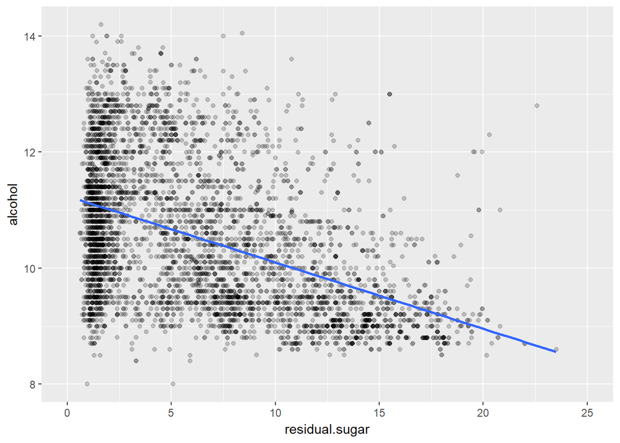

```
## [1] -0.4506312
```

alcohol and the residual sugars are negatively correlated. This show that the higher the alcohol lesser the sugar content. There are correleted with -0.451.

**quality vs alcohol**

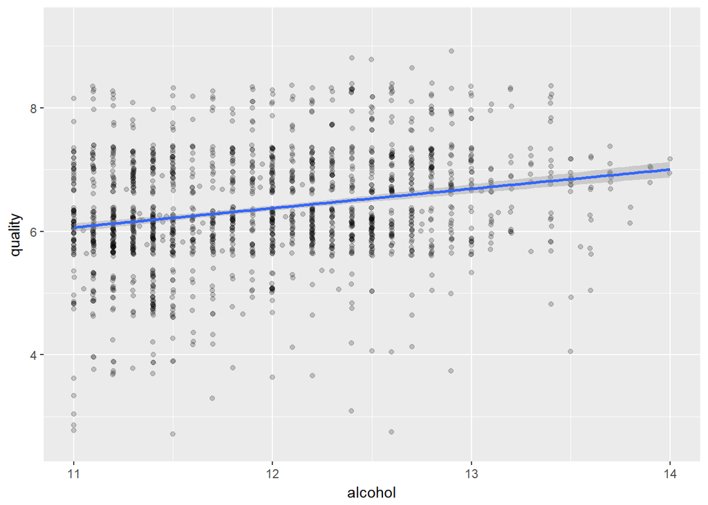

```
## [1] 0.4355747
```

Plot shows that quality and the alcohol are positively correlated with the correlation of 0.4355. There is a chance that wine with higheralcohol leads to high quality wine but correlation does not imply causation , there may be other factors that influence this correlation.

**density vs alcohol**

when calculating the density of the wine , the contents of the denisty of the wine are multiplied with their volume and added to give the wine density.

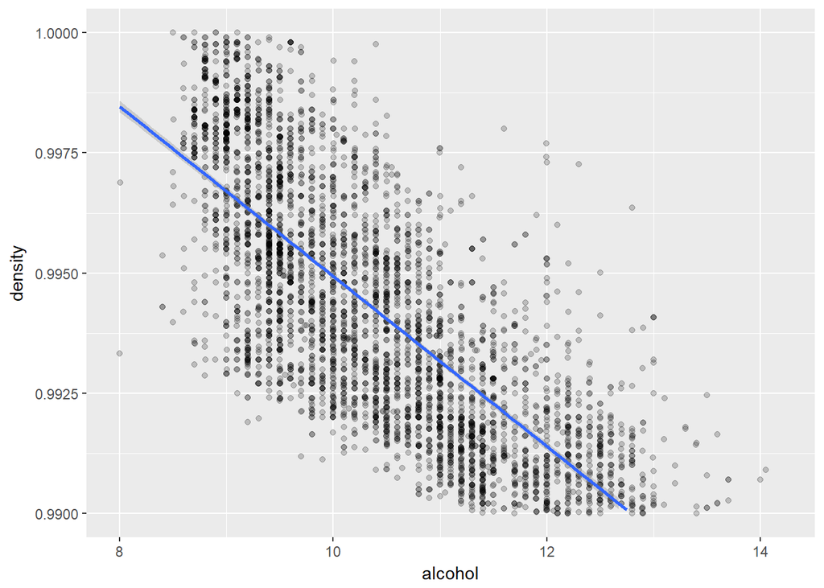

```
## [1] -0.7801376
```

Density and alcohol are negatively correlated with -0.781. It shows that when the alcohol content increases in wine the density of the wine tends to go down.

**density vs residual sugar**

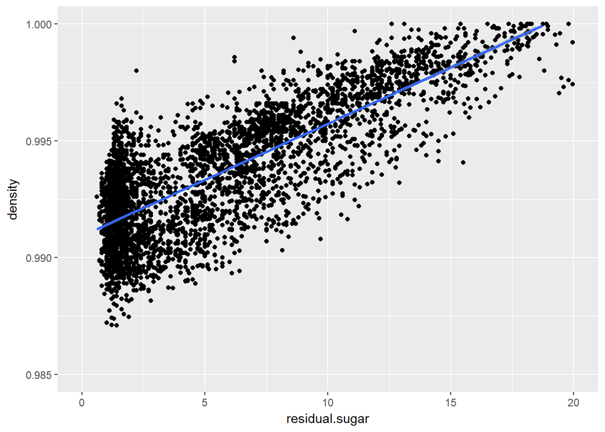

```
## [1] 0.8389665
```

There is a strong correlation between residual sugar and the density. It is a positively correlated with 0.8389. It shows that when residual sugar content in wine increases then the density of the wine also increases.

# Bivariate analysis

**Talk about some of the relationship you observed in this part of the investigation. How did the features of interest vary with the other features in the dataset?**

Quality is the important feature of the dataset. There is no interesting relationship for the quality in the dataset.When the chlorides increases it affects the wine quality as i assume but both are not strongly correlated to prove the assumption.When the alcohol content increases there is a increase in the quality but the strength is not high enough between them to take into] consideration.

**Did you observe any intersting relationship with the other features?**

Important relationship i found is the residual sugar with the alcohol and with the density. During the fermantation sugars are converted into the alcohol.As alcohol is the product of the sugar, it results in the negative correlation between them. In the case of calculating density , density of the contents are considerd. Sugar has the higher density than the alcohol. When the wine has high sugar content then it has a low alcohol content it automatically boost the density to high(sugar has higher density and sugar content high in wine). In other case when wine has high alcohol content then it has low sugar content which in turn makes the density of the wine to low.

**What is the strongest realtionship you found?**

The strongest relationship is between the residual sugars and the density. They are positively correlated with the strength of 0.8389.

# Multivariate Plot Section

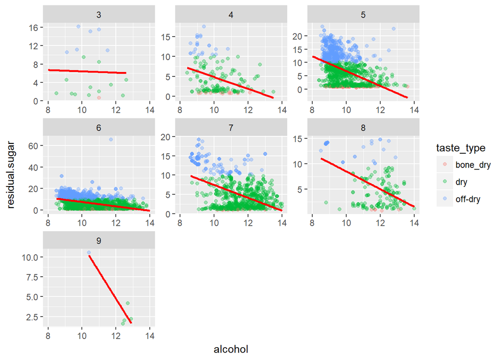

```
## wine$quality: 3
##    Min. 1st Qu.  Median    Mean 3rd Qu.    Max.
##    8.00    9.55   10.45   10.35   11.00   12.60
## --------------------------------------------------------
## wine$quality: 4
##    Min. 1st Qu.  Median    Mean 3rd Qu.    Max.
##    8.40    9.40   10.10   10.15   10.75   13.50
## --------------------------------------------------------
## wine$quality: 5
##    Min. 1st Qu.  Median    Mean 3rd Qu.    Max.
##   8.000   9.200   9.500   9.809  10.300  13.600
## --------------------------------------------------------
## wine$quality: 6
##    Min. 1st Qu.  Median    Mean 3rd Qu.    Max.
##    8.50    9.60   10.50   10.58   11.40   14.00
## --------------------------------------------------------
## wine$quality: 7
##    Min. 1st Qu.  Median    Mean 3rd Qu.    Max.
##    8.60   10.60   11.40   11.37   12.30   14.20
## --------------------------------------------------------
## wine$quality: 8
##    Min. 1st Qu.  Median    Mean 3rd Qu.    Max.
##    8.50   11.00   12.00   11.64   12.60   14.00
## --------------------------------------------------------
## wine$quality: 9
##    Min. 1st Qu.  Median    Mean 3rd Qu.    Max.
##   10.40   12.40   12.50   12.18   12.70   12.90
```

In this plot you can see the cluster of the points shifting from left to right as we go through the quality.It is clearly seen in the quality 5 and quality 7. In quality 5 most of the points are in left side with alcohol range 8 to 12 where as most of the points are in the right of the graph with the alcohol range 10 to 14. And you can also see the wine with the higher sugar content are less in the high quality wine.

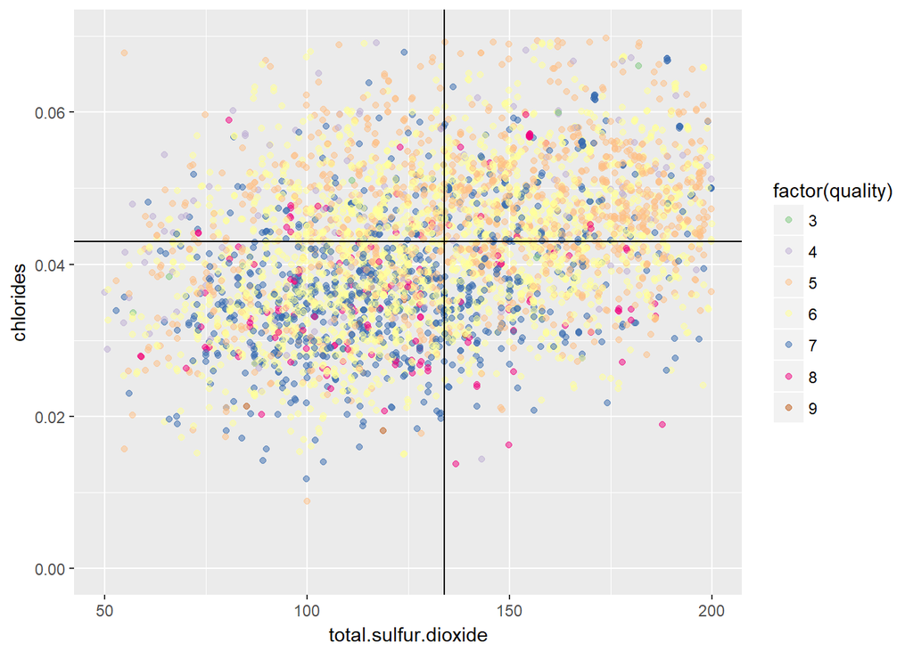

```
## Percentage of the high quality wine with less 50% total chlorides
##     and total sulfur dioxide is
```

```
## [1] 53.58491
```

# Multivariate Analysis

**Talk about some of the relationship you observed in this part of the investigation. Were there features that strengthened each other in terms of look at your feature(s) of interest?**

Considering alcohol, residual sugars and the quality, Most of the high quality wine have high alcohol content and residual sugars are not playing a big part in deciding the quality. when chlorides and the total sulfur dioxide are lower in wine it seems to strengthen the quality of wine.

**were there any interesting or surprising interections between the feature?**

Interesting Interaction is that about 53% of the high quality wine has the chloride and the total sulfur dioxide below their median values.

# Final plots and summary

**Plot one**

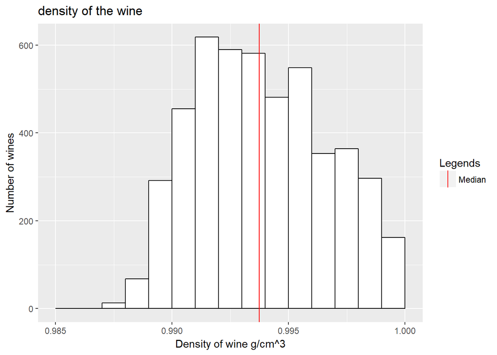

```
##    Min. 1st Qu.  Median    Mean 3rd Qu.    Max.
##  0.9871  0.9917  0.9937  0.9940  0.9961  1.0390
```

**Plot Two**

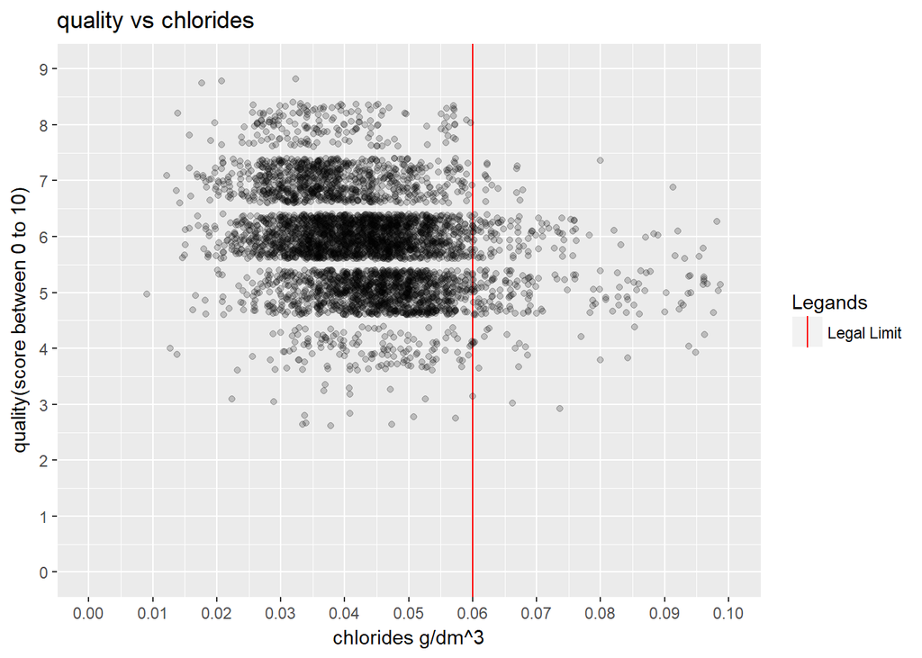

```
## [1] -0.2099344
```

**Description Two**

Chlorides are due to the land where the vineyard is situated. Limit is 0.06 g/dm^3 which may be change in exceptional cases. But increase in the chlorides leads to change in the aroma of the wine which inturn affects the quality of the wine. In this most of high quality wine has chloride content well below the legal limit.

**Plot Three**

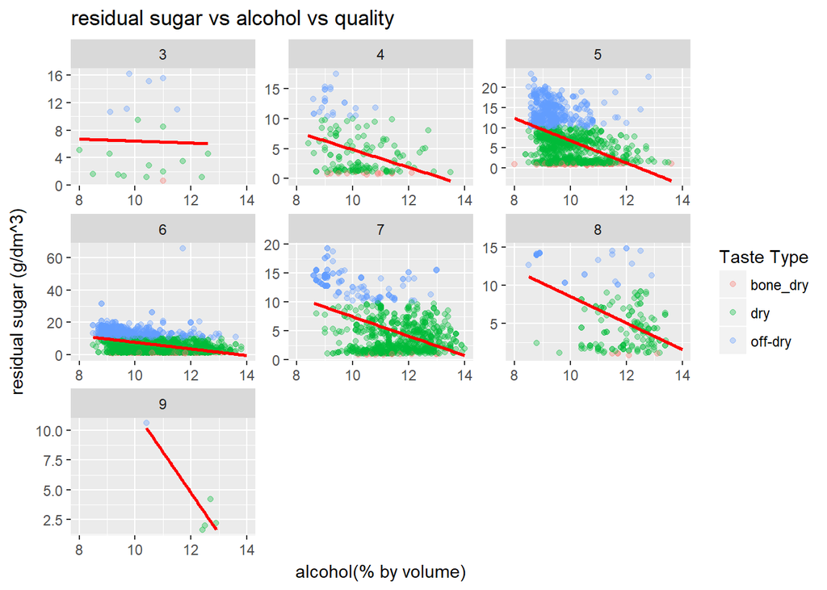

```
## wine$quality: 3
##    Min. 1st Qu.  Median    Mean 3rd Qu.    Max.
##    8.00    9.55   10.45   10.35   11.00   12.60
## --------------------------------------------------------
## wine$quality: 4
##    Min. 1st Qu.  Median    Mean 3rd Qu.    Max.
##    8.40    9.40   10.10   10.15   10.75   13.50
## --------------------------------------------------------
## wine$quality: 5
##    Min. 1st Qu.  Median    Mean 3rd Qu.    Max.
##   8.000   9.200   9.500   9.809  10.300  13.600
## --------------------------------------------------------
## wine$quality: 6
##    Min. 1st Qu.  Median    Mean 3rd Qu.    Max.
##    8.50    9.60   10.50   10.58   11.40   14.00
## --------------------------------------------------------
## wine$quality: 7
##    Min. 1st Qu.  Median    Mean 3rd Qu.    Max.
##    8.60   10.60   11.40   11.37   12.30   14.20
## --------------------------------------------------------
## wine$quality: 8
##    Min. 1st Qu.  Median    Mean 3rd Qu.    Max.
##    8.50   11.00   12.00   11.64   12.60   14.00
## --------------------------------------------------------
## wine$quality: 9
##    Min. 1st Qu.  Median    Mean 3rd Qu.    Max.
##   10.40   12.40   12.50   12.18   12.70   12.90
```

# Reflection

I explored nearly 5000 wines in this dataset.what suprised me is that none of variables are strongly related with the quality. There are some strong relation between density and sugar but these two are not correlated much with the quality. During the winemaking sugars are converted to alcohol, it is reflected in this dataset. And the chlorides content may change the quality of the wine, but there is not enough high quality wines to prove such a point.For residual sugars most of the wines have the low sugar content , thus it fail to show the relation with quality.For future investigation can add the variable like the date of the manufacturing of wine to see the ageing of wine has anything to do with the quality. wine with different chloride content and residual sugar content should be added in future. so that their influence on quality can be found.